# Assignment 3: Profit with Almond Yield

Author

Rachel Swick & Ryan Green

Published

April 21, 2025

```r
# Load packages
library(tidyverse)
library(ggplot2)

# Import the almond yield function
source("almond_yield_anomaly.R")
source("Anomaly_Profit_Function.R")
source("Almond_Profit_Function.R")
```

Develop a profit model for your almond yield

Use your imagination to think about what would make sense Make sure you include parameters You could assume a baseline profit and then adjust according to the anomaly

As of 2/04/25, California Almonds sell for $2.12 a pound according to the Melo Farming Group. 70% of almond farms in California are 100 acres or less according to the Almond Board of California. According to Fruit Growers Supply, one acre of almond orchard produces 2400 lbs of almonds per year

```r
# Run the Almond Profit Function
almond_profit(filepath = "data/clim.txt")
```

```
  min_yield mean_yield max_yield
1  497426.7   77574598 814719564
```

```r
# Sensitivity Analysis on Profit Yield
# Accounting for Variation in Almond Price per Ton and in Yield per Acre, with a 20% variation for each

almond_price_input <- 4240
acre_yield_input <- 1.2
farm_acreage <- 100
clim_file <- "data/clim.txt"

# Parameter 1: Almond Price per Ton
price_seq <- seq(almond_price_input * 0.8,
                 almond_price_input * 1.2,
                 length.out = 3)

# Parameter 2: Yield per Acre
yield_seq <- seq(acre_yield_input * 0.8,
                 acre_yield_input * 1.2,
                 length.out = 3)
```

```r
# Using `expand.grid` to take into account all factor variables
grid_df <- expand.grid(
  almond_price = price_seq,
  acre_yield = yield_seq) %>%
  rowwise() %>%
  mutate(profit = almond_profit(
      almond_price = almond_price,
      farm_acreage = farm_acreage,
      acre_yield = acre_yield,
      filepath = clim_file)) %>%
  ungroup()
head(grid_df)
```

```
# A tibble: 6 × 3
  almond_price acre_yield profit$min_yield $mean_yield $max_yield
         <dbl>      <dbl>            <dbl>       <dbl>      <dbl>
1         3392       0.96          316533.   61978270. 651694243.
2         4240       0.96          395667.   77472838. 814617804.
3         5088       0.96          474800.   92967405. 977541364.
4         3392       1.2           397941.   62059678. 651775651.
5         4240       1.2           497427.   77574598. 814719564.
6         5088       1.2           596912.   93089517. 977663476.
```

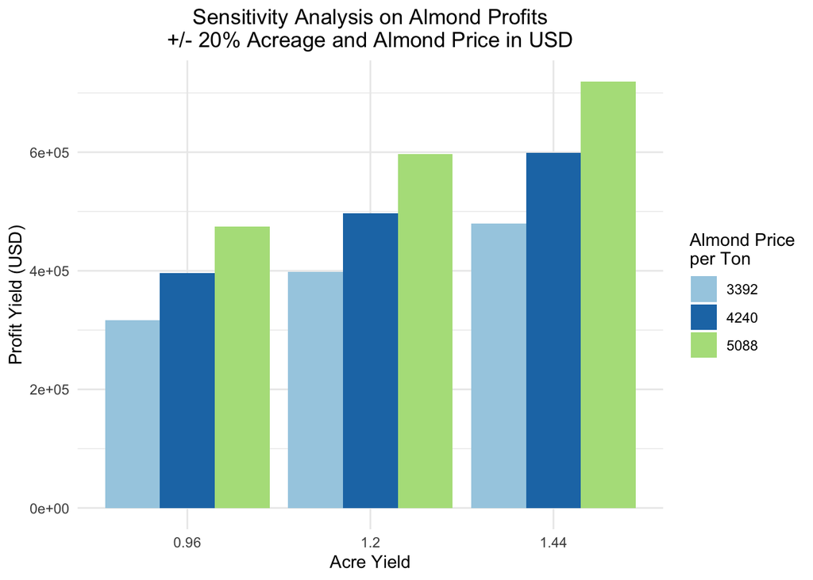

```r
# Plotting Profit Yield by Variation in Acreage and Almond Price
ggplot(grid_df, aes(x = factor(acre_yield), y = profit$min_yield, fill = factor(almond_price))) +
  geom_col(position = "dodge") +
  scale_fill_brewer(palette = "Paired", name = "Almond Price\nper Ton") +
  labs(x = "Acre Yield", y = "Profit Yield (USD)",
       title = "Sensitivity Analysis on Almond Profits\n+/- 20% Acreage and Almond Price in USD") +
  theme_minimal() +
  theme(plot.title = element_text(hjust = 0.5))
```

```
$results
  year yield_anomaly
1 1989    0.06233209
2 1989    0.04808886
3 1989    0.02932479
4 1989    0.02052724
5 1989    0.02023627
6 1989    0.04100198

$plot
```

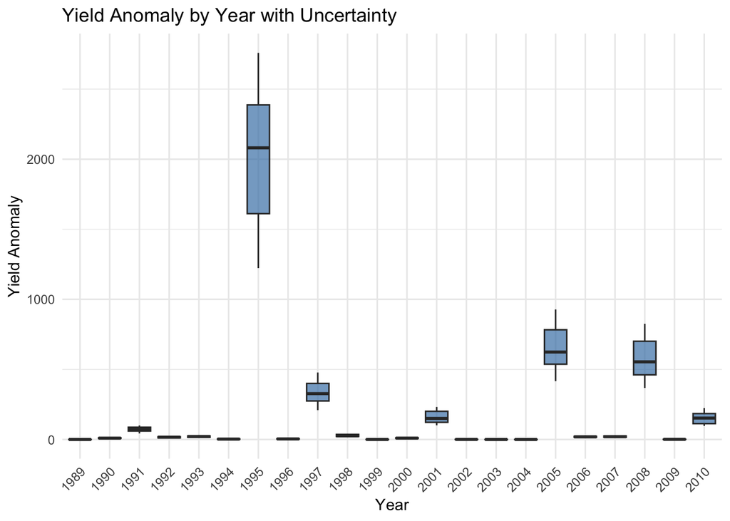

```r
# Run the Almond yield anomaly by year
almond_yield_year("data/clim.txt")
```

The most significant thing I take away from my model results and sensitivity analysis, is that the further the anomaly is from the average, the more sensitive that anomaly is. For instance, in 1995, the anomaly is calculate to be almost 2000 tons per acre. This is an absurd number and suggests something is wrong with the climate data from that year. This is further bolstered by the sensitivity analysis which showed a large potential spread of anomaly values, much larger than other years with smaller anomalies.